# Data_preparing+Model

```python
import seaborn as sns
from matplotlib import pyplot as plt #Для отрисовки графиков
import pandas as pd #Для работы с датасетом
df = pd.read_csv('test_ds_2.csv') #Читаем датасет
df #смотрим
```

|  | Unnamed: 0.1 | Unnamed: 0 | gender | age | hypertension | smoking_history | bmi | HbA1c_level | blood_glucose_level | heart_disease (by Hamilpton system) | physical results | Hipson test | Y |
| --- | --- | --- | --- | --- | --- | --- | --- | --- | --- | --- | --- | --- | --- |
| 0 | 0 | 0 | Female | 80.0 | 0 | never | 25.19 | 6.6 | 140 | 0.0 | 59.17 | 22.73 | 0 |
| 1 | 1 | 1 | Female | 54.0 | 0 | No Info | 27.32 | 6.6 | 80 | 2.0 | 69.15 | 28.25 | 0 |
| 2 | 2 | 2 | Male | 28.0 | 0 | never | 27.32 | 5.7 | 158 | NaN | 37.83 | 24.82 | 0 |
| 3 | 3 | 3 | Female | 36.0 | 0 | current | 23.45 | 5.0 | 155 | NaN | 42.41 | 27.66 | 0 |
| 4 | 4 | 4 | Male | 76.0 | 1 | current | 20.14 | 4.8 | 155 | 2.0 | 58.71 | 26.30 | 0 |
| ... | ... | ... | ... | ... | ... | ... | ... | ... | ... | ... | ... | ... | ... |
| 99995 | 99995 | 99995 | Female | 80.0 | 0 | No Info | 27.32 | 6.2 | 90 | 3.0 | 57.38 | 22.08 | 0 |
| 99996 | 99996 | 99996 | Female | 2.0 | 0 | No Info | 17.37 | 6.5 | 100 | NaN | 53.68 | 23.47 | 0 |
| 99997 | 99997 | 99997 | Male | 66.0 | 0 | former | 27.83 | 5.7 | 155 | NaN | 39.23 | 25.98 | 0 |
| 99998 | 99998 | 99998 | Female | 24.0 | 0 | never | 35.42 | 4.0 | 100 | 2.0 | 54.04 | 25.39 | 0 |
| 99999 | 99999 | 99999 | Female | 57.0 | 0 | current | 22.43 | 6.6 | 90 | 2.0 | 53.62 | 24.95 | 0 |

100000 rows × 13 columns

```python
df.info()
```

```
<class 'pandas.core.frame.DataFrame'>
RangeIndex: 100000 entries, 0 to 99999
Data columns (total 13 columns):
 #   Column                               Non-Null Count   Dtype
---  ------                               --------------   -----
 0   Unnamed: 0.1                         100000 non-null  int64
 1   Unnamed: 0                           100000 non-null  int64
 2   gender                               100000 non-null  object
 3   age                                  100000 non-null  float64
 4   hypertension                         100000 non-null  int64
 5   smoking_history                      100000 non-null  object
 6   bmi                                  100000 non-null  float64
 7   HbA1c_level                          100000 non-null  float64
 8   blood_glucose_level                  100000 non-null  int64
 9   heart_disease (by Hamilpton system)  79995 non-null   float64
 10  physical results                     100000 non-null  float64
 11  Hipson test                          100000 non-null  float64
 12  Y                                    100000 non-null  int64
dtypes: float64(6), int64(5), object(2)
memory usage: 9.9+ MB
```

```python
print(df[df.columns[0]] == df[df.columns[1]])
```

```
0        True
1        True
2        True
3        True
4        True
         ...
99995    True
99996    True
99997    True
99998    True
99999    True
Length: 100000, dtype: bool
```

```python
print(df.iloc()[50000])
```

```
Unnamed: 0.1                             50000
Unnamed: 0                               50000
gender                                  Female
age                                       67.0
hypertension                                 0
smoking_history                        No Info
bmi                                      27.32
HbA1c_level                                4.5
blood_glucose_level                         80
heart_disease (by Hamilpton system)        2.0
physical results                         42.78
Hipson test                               25.4
Y                                            0
Name: 50000, dtype: object
```

Первое, что бросается в глаза, что первые два безымянных столбца не имеют смысловой нагрузки т.к. отображают номер строки, соответственно, от них избавляемся.

```python
del df[df.columns[0]] #Непосредственно удавление двух первых столбцов
del df[df.columns[0]]
df
```

|  | gender | age | hypertension | smoking_history | bmi | HbA1c_level | blood_glucose_level | heart_disease (by Hamilpton system) | physical results | Hipson test | Y |
| --- | --- | --- | --- | --- | --- | --- | --- | --- | --- | --- | --- |
| 0 | Female | 80.0 | 0 | never | 25.19 | 6.6 | 140 | 0.0 | 59.17 | 22.73 | 0 |
| 1 | Female | 54.0 | 0 | No Info | 27.32 | 6.6 | 80 | 2.0 | 69.15 | 28.25 | 0 |
| 2 | Male | 28.0 | 0 | never | 27.32 | 5.7 | 158 | NaN | 37.83 | 24.82 | 0 |
| 3 | Female | 36.0 | 0 | current | 23.45 | 5.0 | 155 | NaN | 42.41 | 27.66 | 0 |
| 4 | Male | 76.0 | 1 | current | 20.14 | 4.8 | 155 | 2.0 | 58.71 | 26.30 | 0 |
| ... | ... | ... | ... | ... | ... | ... | ... | ... | ... | ... | ... |
| 99995 | Female | 80.0 | 0 | No Info | 27.32 | 6.2 | 90 | 3.0 | 57.38 | 22.08 | 0 |
| 99996 | Female | 2.0 | 0 | No Info | 17.37 | 6.5 | 100 | NaN | 53.68 | 23.47 | 0 |
| 99997 | Male | 66.0 | 0 | former | 27.83 | 5.7 | 155 | NaN | 39.23 | 25.98 | 0 |
| 99998 | Female | 24.0 | 0 | never | 35.42 | 4.0 | 100 | 2.0 | 54.04 | 25.39 | 0 |
| 99999 | Female | 57.0 | 0 | current | 22.43 | 6.6 | 90 | 2.0 | 53.62 | 24.95 | 0 |

100000 rows × 11 columns

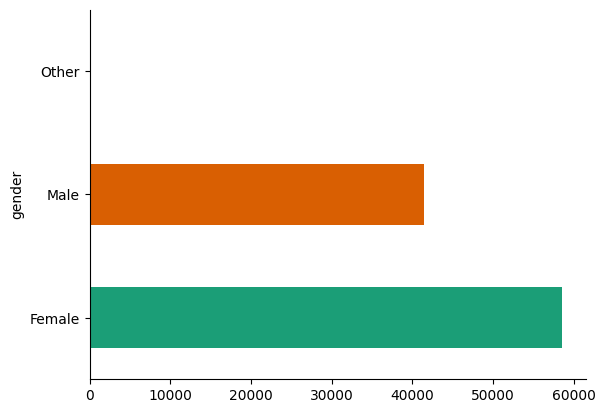

```python
import seaborn as sns
df.groupby('gender').size().plot(kind='barh', color=sns.palettes.mpl_palette('Dark2'))
plt.gca().spines[['top', 'right',]].set_visible(False)
```

```python
df['gender'].value_counts()
```

| gender | count |
| --- | --- |
| Female | 58552 |
| Male | 41430 |
| Other | 18 |

**dtype:** int64

Слишком мало данных по третьему типу. Удаление строк об особях неизвестного пола не навредит данным

```python
df = df[df['gender'] != 'Other']
```

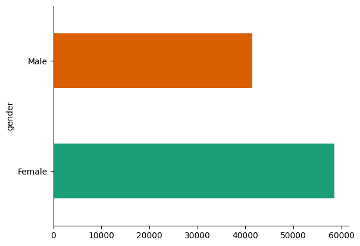

```python
import seaborn as sns
df.groupby('gender').size().plot(kind='barh', color=sns.palettes.mpl_palette('Dark2'))
plt.gca().spines[['top', 'right',]].set_visible(False)
```

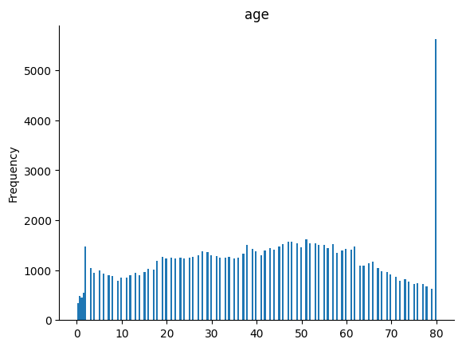

```python
df['age'].plot(kind='hist', bins=200, title='age')
plt.gca().spines[['top', 'right',]].set_visible(False)
```

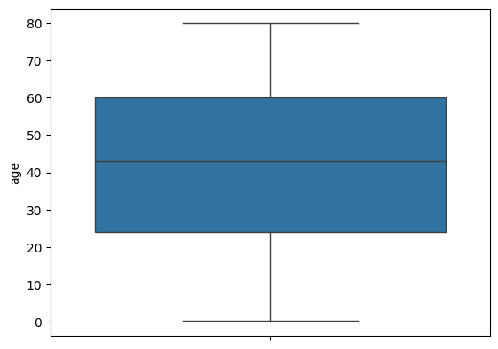

```python
sns.boxplot(df['age'])
plt.show()
```

```python
df['age'].value_counts()
```

| age | count |
| --- | --- |
| 80.00 | 5621 |
| 51.00 | 1619 |
| 47.00 | 1572 |
| 48.00 | 1568 |
| 49.00 | 1541 |
| ... | ... |
| 0.48 | 83 |
| 1.00 | 83 |
| 0.40 | 66 |
| 0.16 | 59 |
| 0.08 | 36 |

102 rows × 1 columns

**dtype:** int64

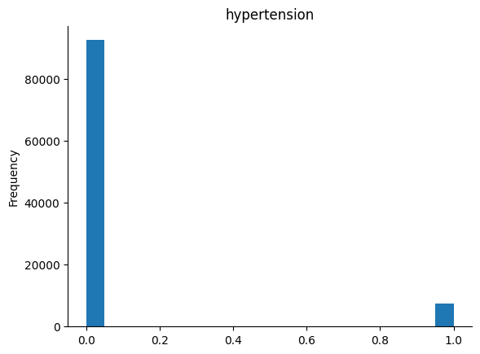

```python
df['hypertension'].plot(kind='hist', bins=20, title='hypertension') #гипертония
plt.gca().spines[['top', 'right',]].set_visible(False)  #todo перерисовать, красиво
```

```python
df['hypertension'].value_counts()
```

| hypertension | count |
| --- | --- |
| 0 | 92497 |
| 1 | 7485 |

**dtype:** int64

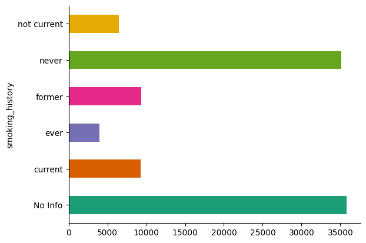

```python
from matplotlib import pyplot as plt
import seaborn as sns
df.groupby('smoking_history').size().plot(kind='barh', color=sns.palettes.mpl_palette('Dark2'))
plt.gca().spines[['top', 'right',]].set_visible(False)
```

```python
df['smoking_history'].value_counts()
```

| smoking_history | count |
| --- | --- |
| No Info | 35810 |
| never | 35092 |
| former | 9352 |
| current | 9286 |
| not current | 6439 |
| ever | 4003 |

**dtype:** int64

Очень много остутствует информации и отпиливать от датасета 36 тысяч строк (36 процентов) или же как - то заполнить не представляется возможным.

```python
del df[df.columns[3]]
df
```

|  | gender | age | hypertension | bmi | HbA1c_level | blood_glucose_level | heart_disease (by Hamilpton system) | physical results | Hipson test | Y |
| --- | --- | --- | --- | --- | --- | --- | --- | --- | --- | --- |
| 0 | Female | 80.0 | 0 | 25.19 | 6.6 | 140 | 0.0 | 59.17 | 22.73 | 0 |
| 1 | Female | 54.0 | 0 | 27.32 | 6.6 | 80 | 2.0 | 69.15 | 28.25 | 0 |
| 2 | Male | 28.0 | 0 | 27.32 | 5.7 | 158 | NaN | 37.83 | 24.82 | 0 |
| 3 | Female | 36.0 | 0 | 23.45 | 5.0 | 155 | NaN | 42.41 | 27.66 | 0 |
| 4 | Male | 76.0 | 1 | 20.14 | 4.8 | 155 | 2.0 | 58.71 | 26.30 | 0 |
| ... | ... | ... | ... | ... | ... | ... | ... | ... | ... | ... |
| 99995 | Female | 80.0 | 0 | 27.32 | 6.2 | 90 | 3.0 | 57.38 | 22.08 | 0 |
| 99996 | Female | 2.0 | 0 | 17.37 | 6.5 | 100 | NaN | 53.68 | 23.47 | 0 |
| 99997 | Male | 66.0 | 0 | 27.83 | 5.7 | 155 | NaN | 39.23 | 25.98 | 0 |
| 99998 | Female | 24.0 | 0 | 35.42 | 4.0 | 100 | 2.0 | 54.04 | 25.39 | 0 |
| 99999 | Female | 57.0 | 0 | 22.43 | 6.6 | 90 | 2.0 | 53.62 | 24.95 | 0 |

99982 rows × 10 columns

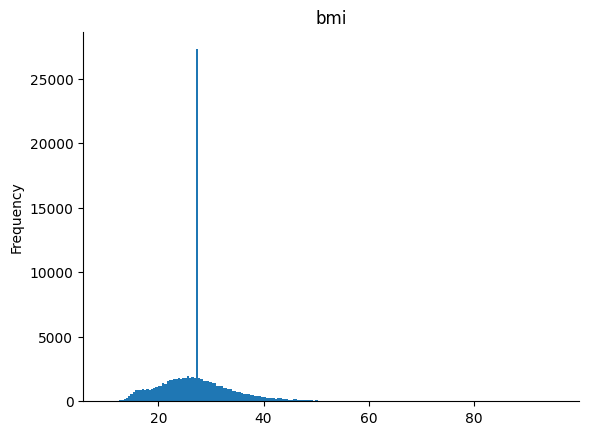

```python
df['bmi'].plot(kind='hist', bins=200, title='bmi') #ИМТ
plt.gca().spines[['top', 'right',]].set_visible(False)
```

```python
df['bmi'].value_counts()
```

| bmi | count |
| --- | --- |
| 27.32 | 25488 |
| 23.00 | 103 |
| 27.12 | 101 |
| 27.80 | 100 |
| 24.96 | 100 |
| ... | ... |
| 53.28 | 1 |
| 55.38 | 1 |
| 40.26 | 1 |
| 51.75 | 1 |
| 60.52 | 1 |

4247 rows × 1 columns

**dtype:** int64

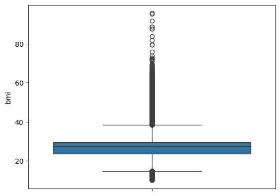

```python
sns.boxplot(df['bmi'])
plt.show()
```

Куча выбросов, поэтому избавимся от них, с помощью IQR, заодно проверим выбросы и по другим признакам

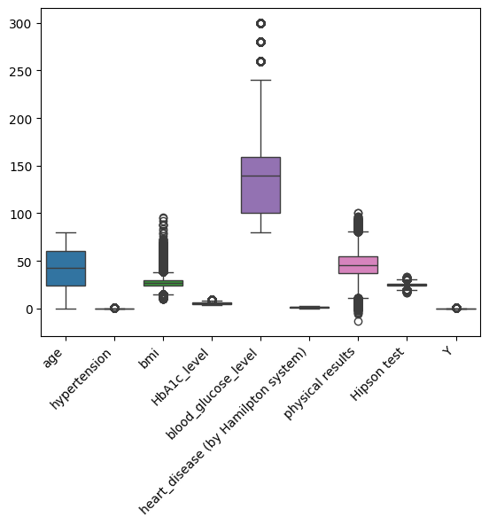

```python
sns.boxplot(df)
plt.xticks(rotation=45, ha='right')
plt.show()
```

```python
df.loc[:, 'hypertension'] = df['hypertension'].astype(bool)
df.loc[:, 'Y'] = df['Y'].astype(bool)
```

```python
data_new = df.select_dtypes('number')
quantiles = data_new.quantile([0.25, 0.75])
quantiles
```

|  | age | bmi | HbA1c_level | blood_glucose_level | heart_disease (by Hamilpton system) | physical results | Hipson test |
| --- | --- | --- | --- | --- | --- | --- | --- |
| 0.25 | 24.0 | 23.63 | 4.8 | 100.0 | 1.0 | 37.20 | 23.65 |
| 0.75 | 60.0 | 29.58 | 6.2 | 159.0 | 2.0 | 54.63 | 26.35 |

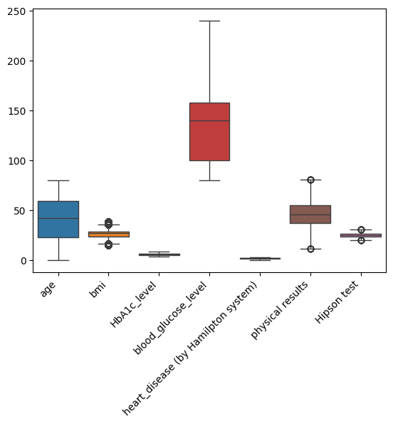

```python
tmp = df.select_dtypes('number')
q1 = tmp.quantile(0.25)
q3 = tmp.quantile(0.75)
q_range = q3 - q1

df_without_anomalies = tmp[~((tmp < (q1 - 1.5 * q_range)) | (tmp > (q3 + 1.5 * q_range))).any(axis=1)]
sns.boxplot(df_without_anomalies)
plt.xticks(rotation=45, ha='right')
plt.show()
```

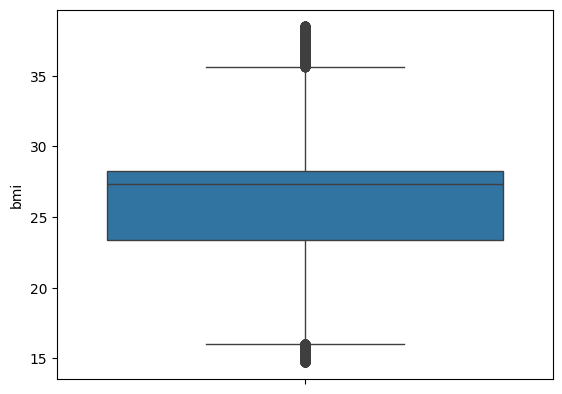

```python
sns.boxplot(df_without_anomalies['bmi'])
plt.show()
```

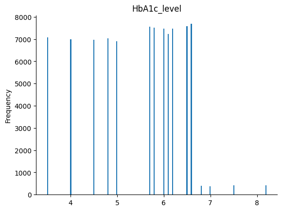

```python
# гликогемоглобин
df_without_anomalies['HbA1c_level'].plot(kind='hist', bins=200, title='HbA1c_level')
plt.gca().spines[['top', 'right',]].set_visible(False)
```

```python
df_without_anomalies['HbA1c_level'].value_counts()
```

| HbA1c_level | count |
| --- | --- |
| 6.6 | 7686 |
| 6.5 | 7572 |
| 5.7 | 7558 |
| 5.8 | 7517 |
| 6.2 | 7480 |
| 6.0 | 7466 |
| 6.1 | 7241 |
| 3.5 | 7072 |
| 4.8 | 7037 |
| 4.0 | 6989 |
| 4.5 | 6981 |
| 5.0 | 6898 |
| 7.5 | 421 |
| 8.2 | 411 |
| 6.8 | 393 |
| 7.0 | 374 |

**dtype:** int64

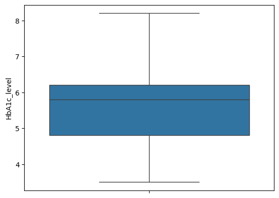

```python
sns.boxplot(df_without_anomalies['HbA1c_level'])
plt.show()
```

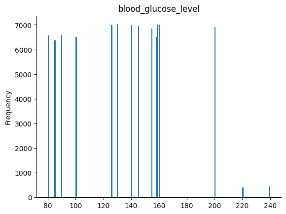

```python
df_without_anomalies['blood_glucose_level'].plot(kind='hist', bins=200, title='blood_glucose_level')
plt.gca().spines[['top', 'right',]].set_visible(False)
```

```python
df_without_anomalies['blood_glucose_level'].value_counts()
```

| blood_glucose_level | count |
| --- | --- |
| 130 | 7022 |
| 159 | 7007 |
| 140 | 6996 |
| 126 | 6995 |
| 160 | 6978 |
| 145 | 6953 |
| 200 | 6901 |
| 155 | 6850 |
| 90 | 6579 |
| 80 | 6560 |
| 158 | 6516 |
| 100 | 6503 |
| 85 | 6372 |
| 240 | 454 |
| 220 | 410 |

**dtype:** int64

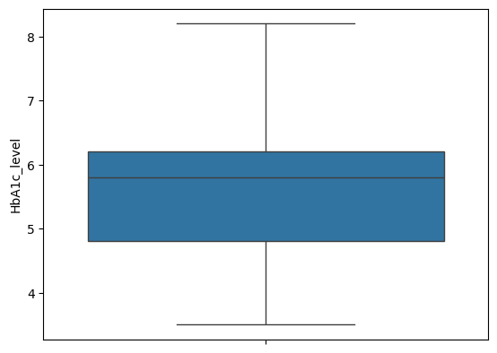

```python
sns.boxplot(df_without_anomalies['HbA1c_level'])
plt.show()
```

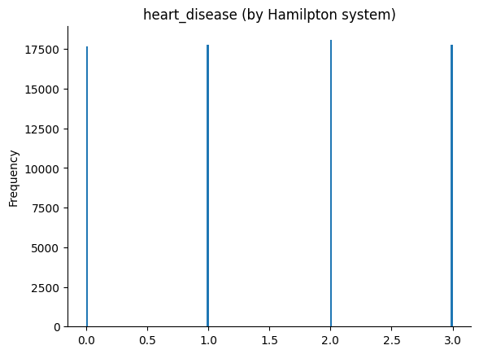

```python
df_without_anomalies['heart_disease (by Hamilpton system)'].plot(kind='hist', bins=200, title='heart_disease (by Hamilpton system)')
plt.gca().spines[['top', 'right',]].set_visible(False)
```

```python
df_without_anomalies['heart_disease (by Hamilpton system)'].value_counts()
```

| heart_disease (by Hamilpton system) | count |
| --- | --- |
| 2.0 | 18061 |
| 1.0 | 17791 |
| 3.0 | 17749 |
| 0.0 | 17669 |

**dtype:** int64

```python
df_without_anomalies.info()
```

```
<class 'pandas.core.frame.DataFrame'>
Index: 89096 entries, 0 to 99999
Data columns (total 7 columns):
 #   Column                               Non-Null Count  Dtype
---  ------                               --------------  -----
 0   age                                  89096 non-null  float64
 1   bmi                                  89096 non-null  float64
 2   HbA1c_level                          89096 non-null  float64
 3   blood_glucose_level                  89096 non-null  int64
 4   heart_disease (by Hamilpton system)  71270 non-null  float64
 5   physical results                     89096 non-null  float64
 6   Hipson test                          89096 non-null  float64
dtypes: float64(6), int64(1)
memory usage: 5.4 MB
```

```python
df_without_anomalies.loc[:,'heart_disease (by Hamilpton system)'] = df_without_anomalies['heart_disease (by Hamilpton system)'].fillna(df_without_anomalies['heart_disease (by Hamilpton system)'].mean())
```

Заполнили пропуски средним арифметическим

```python
df_without_anomalies
```

|  | age | bmi | HbA1c_level | blood_glucose_level | heart_disease (by Hamilpton system) | physical results | Hipson test |
| --- | --- | --- | --- | --- | --- | --- | --- |
| 0 | 80.0 | 25.19 | 6.6 | 140 | 0.000000 | 59.17 | 22.73 |
| 1 | 54.0 | 27.32 | 6.6 | 80 | 2.000000 | 69.15 | 28.25 |
| 2 | 28.0 | 27.32 | 5.7 | 158 | 1.503578 | 37.83 | 24.82 |
| 3 | 36.0 | 23.45 | 5.0 | 155 | 1.503578 | 42.41 | 27.66 |
| 4 | 76.0 | 20.14 | 4.8 | 155 | 2.000000 | 58.71 | 26.30 |
| ... | ... | ... | ... | ... | ... | ... | ... |
| 99995 | 80.0 | 27.32 | 6.2 | 90 | 3.000000 | 57.38 | 22.08 |
| 99996 | 2.0 | 17.37 | 6.5 | 100 | 1.503578 | 53.68 | 23.47 |
| 99997 | 66.0 | 27.83 | 5.7 | 155 | 1.503578 | 39.23 | 25.98 |
| 99998 | 24.0 | 35.42 | 4.0 | 100 | 2.000000 | 54.04 | 25.39 |
| 99999 | 57.0 | 22.43 | 6.6 | 90 | 2.000000 | 53.62 | 24.95 |

89096 rows × 7 columns

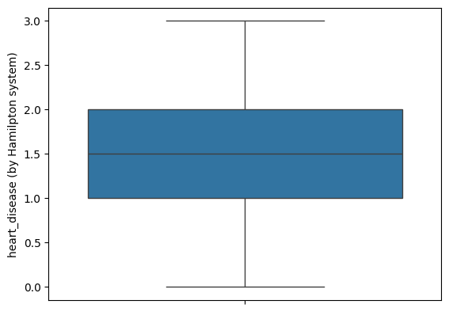

```python
sns.boxplot(df_without_anomalies['heart_disease (by Hamilpton system)'])#матожидание не входит в категориальные, надо пересмотреть
plt.show()
```

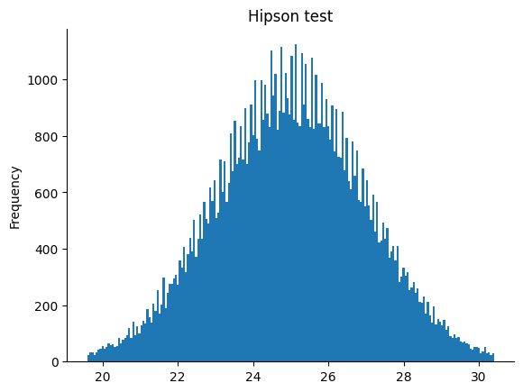

```python
df_without_anomalies['Hipson test'].plot(kind='hist', bins=200, title='Hipson test')
plt.gca().spines[['top', 'right',]].set_visible(False)
```

```python
df_without_anomalies['Hipson test'].value_counts()
```

| Hipson test | count |
| --- | --- |
| 25.04 | 209 |
| 25.14 | 207 |
| 24.74 | 204 |
| 25.56 | 204 |
| 24.82 | 202 |
| ... | ... |
| 19.80 | 2 |
| 19.63 | 2 |
| 19.88 | 2 |
| 19.75 | 2 |
| 30.32 | 2 |

1081 rows × 1 columns

**dtype:** int64

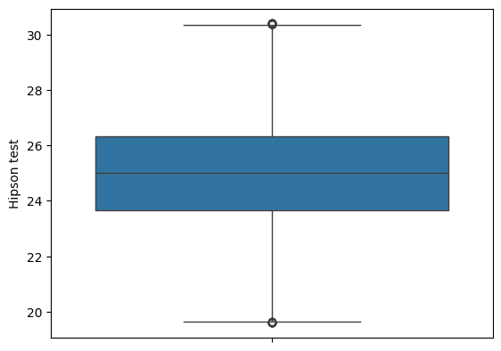

```python
sns.boxplot(df_without_anomalies['Hipson test'])
plt.show()
```

```python
df_without_anomalies.duplicated().sum()
```

```
0
```

```python
df_without_anomalies.loc[:, 'hypertension'] = df.loc[:,'hypertension']
df_without_anomalies
```

|  | age | bmi | HbA1c_level | blood_glucose_level | heart_disease (by Hamilpton system) | physical results | Hipson test | hypertension |
| --- | --- | --- | --- | --- | --- | --- | --- | --- |
| 0 | 80.0 | 25.19 | 6.6 | 140 | 0.000000 | 59.17 | 22.73 | False |
| 1 | 54.0 | 27.32 | 6.6 | 80 | 2.000000 | 69.15 | 28.25 | False |
| 2 | 28.0 | 27.32 | 5.7 | 158 | 1.503578 | 37.83 | 24.82 | False |
| 3 | 36.0 | 23.45 | 5.0 | 155 | 1.503578 | 42.41 | 27.66 | False |
| 4 | 76.0 | 20.14 | 4.8 | 155 | 2.000000 | 58.71 | 26.30 | True |
| ... | ... | ... | ... | ... | ... | ... | ... | ... |
| 99995 | 80.0 | 27.32 | 6.2 | 90 | 3.000000 | 57.38 | 22.08 | False |
| 99996 | 2.0 | 17.37 | 6.5 | 100 | 1.503578 | 53.68 | 23.47 | False |
| 99997 | 66.0 | 27.83 | 5.7 | 155 | 1.503578 | 39.23 | 25.98 | False |
| 99998 | 24.0 | 35.42 | 4.0 | 100 | 2.000000 | 54.04 | 25.39 | False |
| 99999 | 57.0 | 22.43 | 6.6 | 90 | 2.000000 | 53.62 | 24.95 | False |

89096 rows × 8 columns

```python
df.describe()
```

|  | age | bmi | HbA1c_level | blood_glucose_level | heart_disease (by Hamilpton system) | physical results | Hipson test |
| --- | --- | --- | --- | --- | --- | --- | --- |
| count | 99982.000000 | 99982.000000 | 99982.000000 | 99982.000000 | 79984.000000 | 99982.000000 | 99982.000000 |
| mean | 41.888076 | 27.320757 | 5.527529 | 138.057810 | 1.504151 | 45.939764 | 25.002394 |
| std | 22.517206 | 6.636853 | 1.070665 | 40.709469 | 1.115324 | 12.984378 | 2.001191 |
| min | 0.080000 | 10.010000 | 3.500000 | 80.000000 | 0.000000 | -13.020000 | 16.460000 |
| 25% | 24.000000 | 23.630000 | 4.800000 | 100.000000 | 1.000000 | 37.200000 | 23.650000 |
| 50% | 43.000000 | 27.320000 | 5.800000 | 140.000000 | 2.000000 | 45.930000 | 25.000000 |
| 75% | 60.000000 | 29.580000 | 6.200000 | 159.000000 | 2.000000 | 54.630000 | 26.350000 |
| max | 80.000000 | 95.690000 | 9.000000 | 300.000000 | 3.000000 | 100.110000 | 33.000000 |

```python
df_without_anomalies.loc[:,'gender'] = df.loc[:,'gender']
df_without_anomalies.loc[:, 'Y'] = df.loc[:,'Y']
```

```python
from scipy.stats import ttest_ind
for feature in df_without_anomalies.select_dtypes('number'):
    group0 = df_without_anomalies[df_without_anomalies['Y'] == 0][feature]
    group1 = df_without_anomalies[df_without_anomalies['Y'] == 1][feature]
    t_stat, p_value = ttest_ind(group0, group1)
    print(f"{feature} p-value: {p_value}")
```

```
age p-value: 0.0
bmi p-value: 0.0
HbA1c_level p-value: 0.0
blood_glucose_level p-value: 0.0
heart_disease (by Hamilpton system) p-value: 0.9109447429726665
physical results p-value: 0.8119106896639585
Hipson test p-value: 0.9028642114429833
```

```python
from scipy.stats import mannwhitneyu
for feature in ['heart_disease (by Hamilpton system)', 'physical results', 'Hipson test']:
    group0 = df_without_anomalies[df_without_anomalies['Y'] == 0][feature]
    group1 = df_without_anomalies[df_without_anomalies['Y'] == 1][feature]
    stat, p = mannwhitneyu(group0, group1)
    print(f"{feature} p-value: {p}")
```

```
heart_disease (by Hamilpton system) p-value: 0.8476788124797483
physical results p-value: 0.639916172877578
Hipson test p-value: 0.9617487938563727
```

```python
from scipy.stats import chi2_contingency
for feature in df_without_anomalies.select_dtypes('object'):
    contingency_table = pd.crosstab(df_without_anomalies[feature], df_without_anomalies['Y'])
    chi2, p, _, _ = chi2_contingency(contingency_table)
    print(f"{feature} p-value: {p:.4f}")
```

```
gender p-value: 0.0000
```

Мы можем спокойно удалять три столбца, которые по критериям не связаны с целевой переменной (p-value > 0.05)

```python
df_without_anomalies = df_without_anomalies.drop(['heart_disease (by Hamilpton system)', 'physical results', 'Hipson test'], axis = 1)
```

```python
from sklearn.linear_model import LogisticRegression
from sklearn.ensemble import RandomForestClassifier
from xgboost import XGBClassifier  #Используемые классификаторы
from sklearn.preprocessing import StandardScaler, OneHotEncoder #нормализатор и кодировщик категориальных признаков

df_without_anomalies = pd.get_dummies(df_without_anomalies, columns=['gender'], drop_first=True)
```

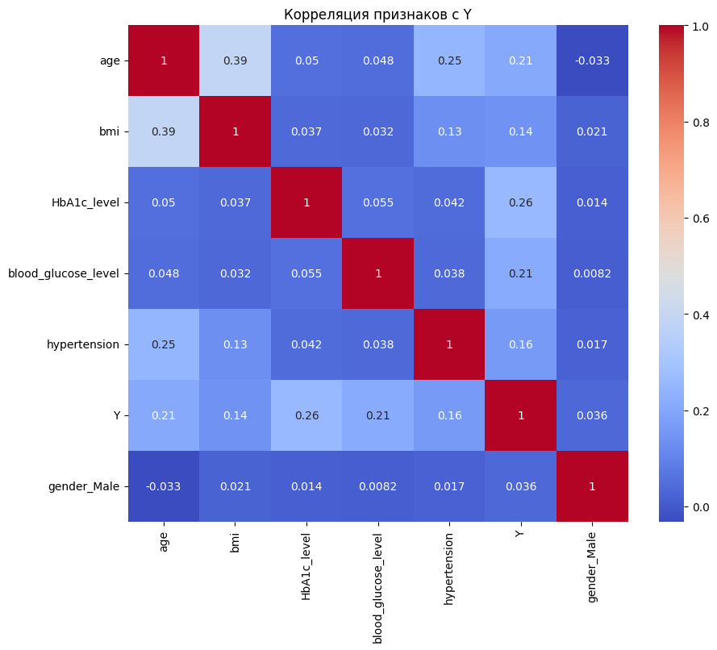

```python
plt.figure(figsize=(10, 8))
sns.heatmap(df_without_anomalies.corr(), annot=True, cmap='coolwarm')
plt.title('Корреляция признаков с Y')
plt.show()
```

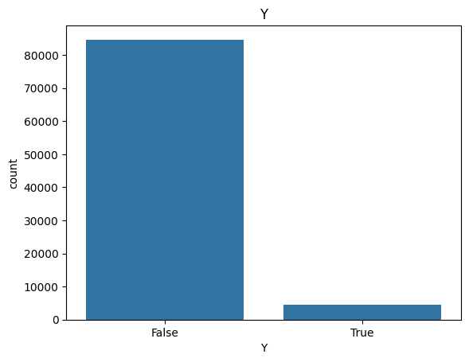

```python
sns.countplot(x='Y', data=df_without_anomalies)
plt.title('Y')
plt.show()
```

Сильный дисбаланс классов на лицо, нужно сбалансировать

```python
from imblearn.over_sampling import SMOTE
smote = SMOTE()
X = df_without_anomalies.drop('Y', axis=1)
y = df_without_anomalies[['Y']]
X_resampled, y_resampled = smote.fit_resample(X, y)
'''SMOTE работает путем генерации новых примеров класса-меньшинства на основе близлежащих соседей.
 Этот метод помогает сделать распределение классов более равномерным, сохраняя структуру данных.'''
```

```
'SMOTE работает путем генерации новых примеров класса-меньшинства на основе близлежащих соседей.\n Этот метод помогает сделать распределение классов более равномерным, сохраняя структуру данных.'
```

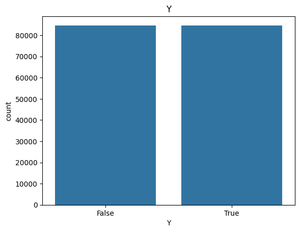

```python
sns.countplot(x='Y', data=y_resampled)
plt.title('Y')
plt.show()
```

```python
from sklearn.model_selection import train_test_split
X_train, X_test, y_train, y_test = train_test_split(X_resampled, y_resampled, test_size=0.2)
X_train
```

|  | age | bmi | HbA1c_level | blood_glucose_level | hypertension | gender_Male |
| --- | --- | --- | --- | --- | --- | --- |
| 120946 | 65.431966 | 36.874730 | 6.261556 | 140 | False | False |
| 118481 | 65.849150 | 30.832727 | 6.464235 | 160 | False | False |
| 772 | 37.000000 | 24.960000 | 6.200000 | 158 | False | False |
| 125109 | 75.000000 | 30.917284 | 6.286797 | 220 | True | False |
| 38794 | 26.000000 | 35.000000 | 6.200000 | 85 | False | True |
| ... | ... | ... | ... | ... | ... | ... |
| 90963 | 39.310639 | 28.320000 | 6.577660 | 159 | True | True |
| 135346 | 40.284750 | 27.720540 | 6.697976 | 140 | False | True |
| 131866 | 68.000000 | 26.898660 | 6.873919 | 155 | False | True |
| 130230 | 61.399965 | 26.577972 | 6.319972 | 160 | False | True |
| 10381 | 63.000000 | 27.110000 | 6.500000 | 145 | False | True |

135446 rows × 6 columns

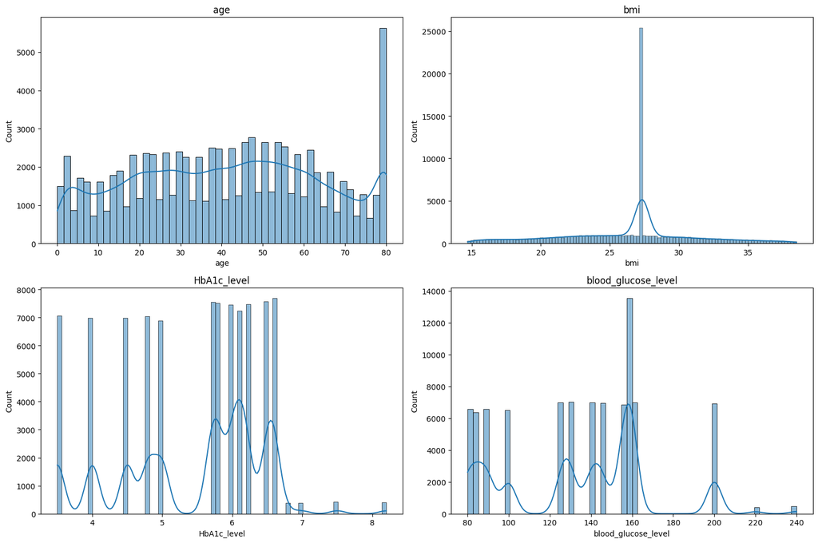

```python
scaler = StandardScaler()
X_train = scaler.fit_transform(X_train)
X_test = scaler.transform(X_test)
plt.figure(figsize=(15, 10))
for i, col in enumerate(['age', 'bmi', 'HbA1c_level', 'blood_glucose_level']):
    plt.subplot(2, 2, i+1)
    sns.histplot(df_without_anomalies[col], kde=True)
    plt.title(f'{col}')
plt.tight_layout()
plt.show()
```

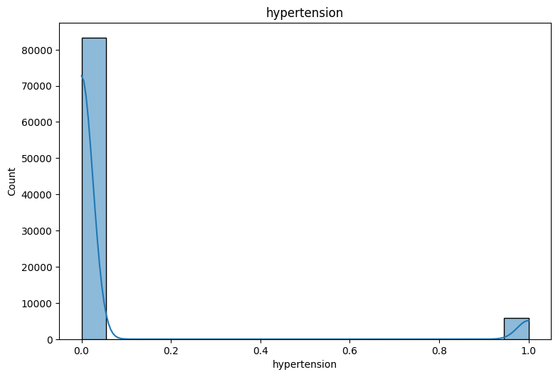

```python
plt.figure(figsize=(15, 10))
for i, col in enumerate(['hypertension']):
    plt.subplot(2, 2, i+1)
    sns.histplot(df_without_anomalies[col], kde=True)
    plt.title(f'{col}')
plt.tight_layout()
plt.show()
```

```python
models = {
    "Logistic Regression": LogisticRegression(),
    "Random Forest": RandomForestClassifier(random_state=42),
    "XGBoost": XGBClassifier(random_state=42, use_label_encoder=False, eval_metric='logloss')
}
```

```python
import time
```

```
Время предсказания: 0.0064
```

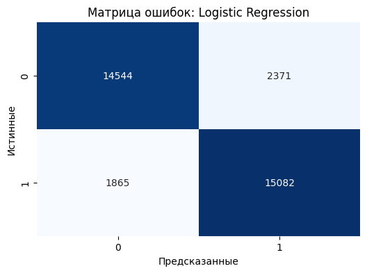

```
               Feature  Coefficient
2          HbA1c_level     2.449025
3  blood_glucose_level     1.146820
0                  age     1.131509
4         hypertension     0.580658
5          gender_Male     0.562868
1                  bmi     0.502131
```

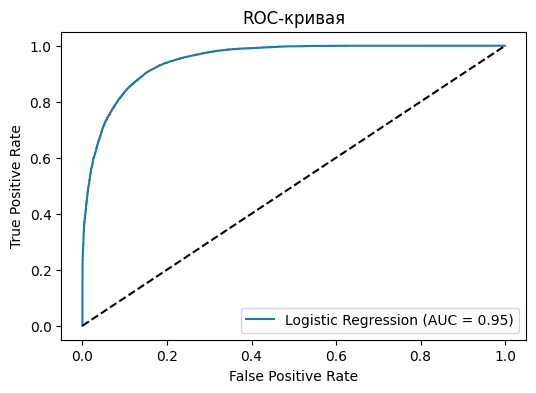

```
Время предсказания: 1.4105
```

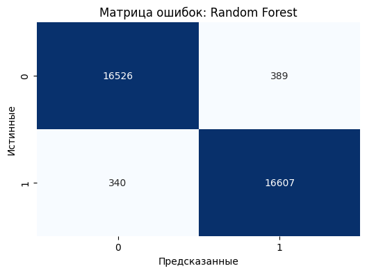

```
               Feature  Importance
2          HbA1c_level    0.408275
0                  age    0.230683
3  blood_glucose_level    0.203476
1                  bmi    0.082407
4         hypertension    0.052024
5          gender_Male    0.023134
```

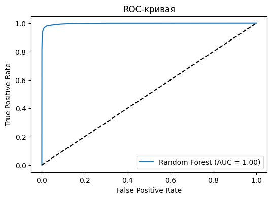

```
Время предсказания: 0.3332
```

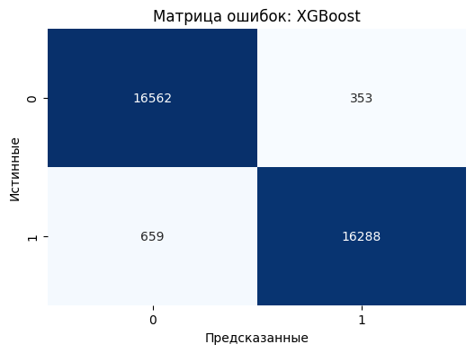

```
               Feature  Importance
2          HbA1c_level    0.550170
3  blood_glucose_level    0.160591
4         hypertension    0.124104
0                  age    0.074928
5          gender_Male    0.072471
1                  bmi    0.017737
```

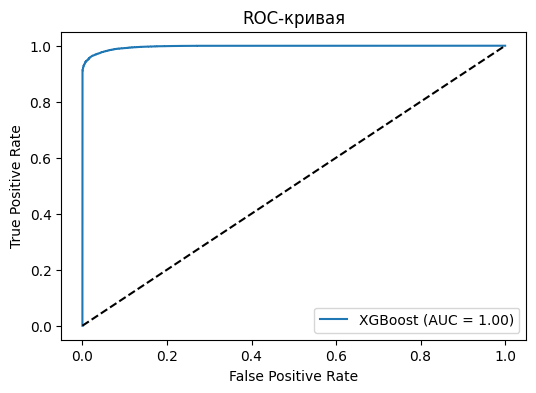

```
                     Accuracy  F1 Score   ROC AUC
Logistic Regression  0.874904  0.876860  0.950527
Random Forest        0.978471  0.978523  0.997358
XGBoost              0.970114  0.969870  0.996845
```

```python
from sklearn.metrics import accuracy_score, f1_score, roc_auc_score, confusion_matrix, roc_curve
results = {}
for name, model in models.items():
    model.fit(X_train, y_train)
    st = time.process_time()
    y_pred = model.predict(X_test)
    y_proba = model.predict_proba(X_test)[:, 1]
    et = time.process_time()
    print(f'Время предсказания: {et - st:.4f}')
    accuracy = accuracy_score(y_test, y_pred) #точность
    f1 = f1_score(y_test, y_pred) #среднее значение Точности измерений (Accuracy) и Отзыва (Recall)
    roc_auc = roc_auc_score(y_test, y_proba) #оценка производительности модели

    results[name] = {
        "Accuracy": accuracy,
        "F1 Score": f1,
        "ROC AUC": roc_auc
    }

    # Матрица ошибок
    cm = confusion_matrix(y_test, y_pred)
    plt.figure(figsize=(6, 4))
    sns.heatmap(cm, annot=True, fmt='d', cmap='Blues', cbar=False)
    plt.title(f'Матрица ошибок: {name}')
    plt.xlabel('Предсказанные')
    plt.ylabel('Истинные')
    plt.show()

    if name != 'Logistic Regression':
        feature_importance = pd.DataFrame({
        'Feature': X.columns,
        'Importance': model.feature_importances_
        }).sort_values(by='Importance', ascending=False)
    else:
        feature_importance = pd.DataFrame({
        'Feature': X.columns,
        'Coefficient': model.coef_[0]
        }).sort_values(by='Coefficient', ascending=False)
    print(feature_importance)

    fpr, tpr, _ = roc_curve(y_test, y_proba)
    plt.figure(figsize=(6, 4))
    plt.plot(fpr, tpr, label=f'{name} (AUC = {roc_auc:.2f})')
    plt.plot([0, 1], [0, 1], 'k--')
    plt.xlabel('False Positive Rate')
    plt.ylabel('True Positive Rate')
    plt.title('ROC-кривая')
    plt.legend()
    plt.show()

# Результаты
results_df = pd.DataFrame(results).T
print(results_df)
```

Лучше всего по качеству себя показала модель RandomForest, т.к. наиболее точна и по производительнсти уступает лишь бустингу (если считать за производительность точность/время). Самая быстрая это логистическая регрессия, но и самая не точная. XGBoost быстрее RandomForest, но качеством немного уступает. Думаю, что если внедрять в какое- то медицинское оборудование, то можно использовать RandomForest, т.к. относительно посещаемости пациентов, оно не является высоконагруженным, а значит разница по времени с XGBoost не принципиальна.